# Analyzing Individual BGG Users

Phil Henrickson

2022-01-01

# **Spire_Rubica’s** BoardGameGeek Collection

This notebook contains a set of analyses for the selected user’s boardgamegeek collection. The bulk of the analysis is focused on building a user-specific predictive model to predict the games that Spire_Rubica is likely to own. This enables to ask questions like, based on the games the user currently owns, what games are a good fit for their collection? What upcoming games are they likely to purchase?

This analysis is based on data from BoardGameGeek that was last updated on **2021-12-20.**

# 1 Collection Overview

We can look at a basic description of the number of games that the user owns, has rated, has previously owned, etc.

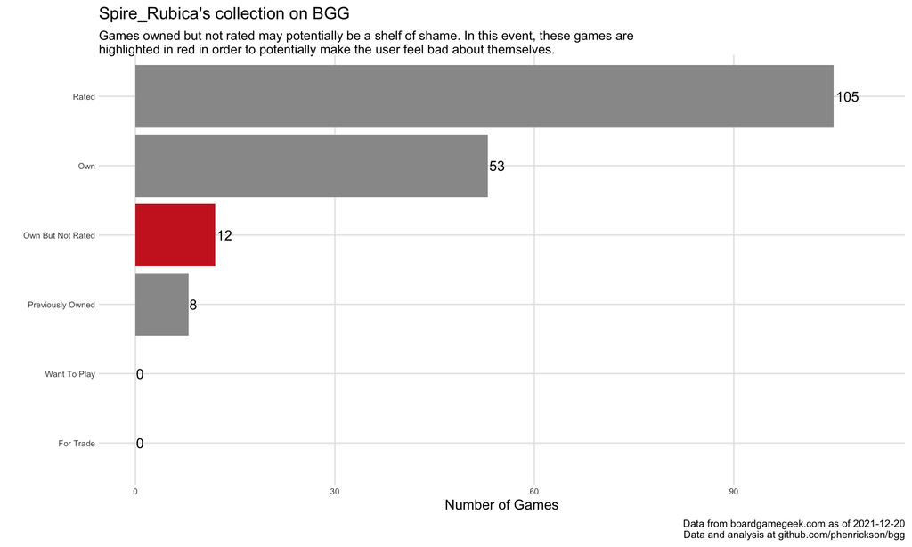

What years has the user owned/rated games from? While we can’t see when a user added or removed a game from their collection, we can look at their collection by the years in which their games were published.

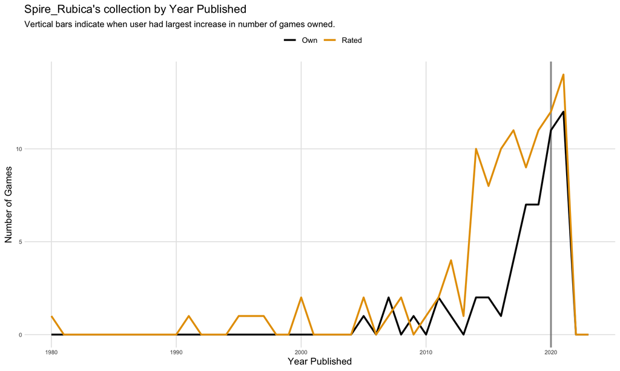

## 1.1 What types of games does Spire_Rubica own?

We can look at the most frequent types of categories, mechanics, designers, and artists that appear in a user’s collection.

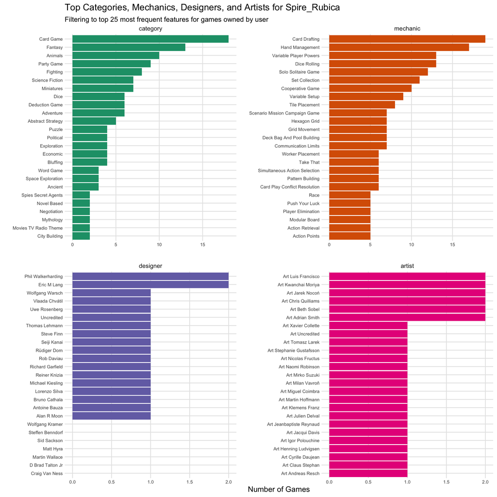

# 2 Modeling **Spire_Rubica’s** Collection

| username | dataset | period | games_owned | games_rated | games_played |
| --- | --- | --- | --- | --- | --- |
| Spire_Rubica | training | published before 2020 | 29 | 78 | 88 |
| Spire_Rubica | test | published 2020 or later | 23 | 26 | 30 |

There are two main (binary) outcomes we will be modeling for the user.

The first, **own** refers to whether the user currently lists a game as owned in their collection. The second, **played** refers to whether the user currently owns, has rated, or previously owned a game. This means the latter will generally have a larger list of games, but may still be a useful category to examine for people who play lots of games without necessarily owning them.

We will train predictive models to learn the probability that the user will own or play individual games based on their features.

## 2.1 Coefficients for Spire_Rubica

We can examine coefficients from the trained modes, which are penalized logistic regressions fit to our two main outcomes. Positive values indicate that a feature increases a user’s probabilility of owning/rating a game, while negative values indicate a feature decreases the probability.

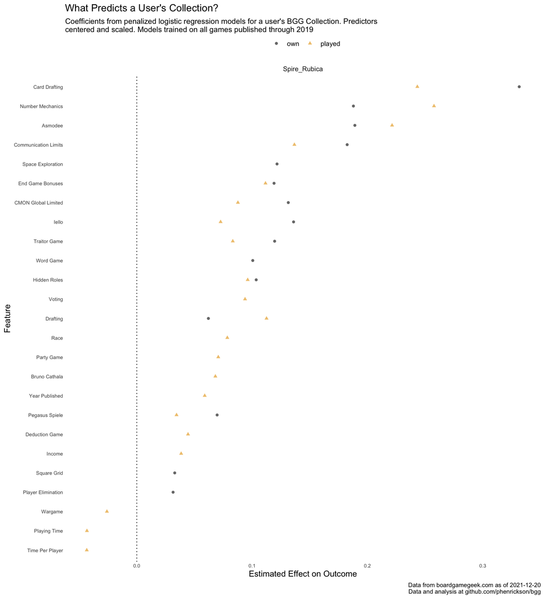

## 2.2 Visualizing Predictors for Spire_Rubica’s Collection

Why did the model identify these features? We can make density plots of the important features for predicting whether the user owned a game. Blue indicates the density for games owned by the user, while grey indicates the density for games not owned by the user.

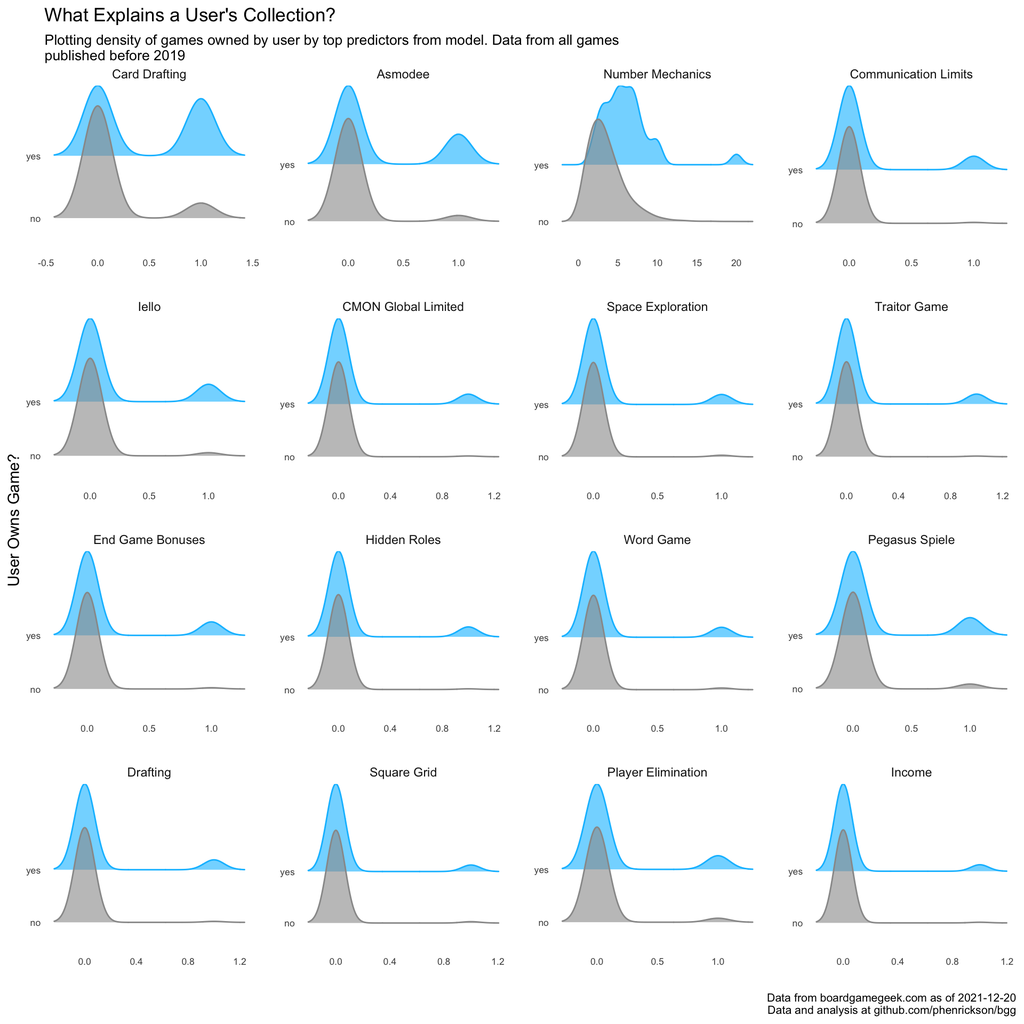

Binary predictors can be difficult to see with this visualization, so we can also directly examine the percentage of games in a user’s collection with a predictor vs the percentage of all games with that predictor.

| username | Feature | % of Games with Feature In_Collection | % of Games with Feature All_Games | Ratio |
| --- | --- | --- | --- | --- |
| Spire_Rubica | Traitor Game | 10.3% | 0.6% | 16.0 |
| Spire_Rubica | Hidden Roles | 10.3% | 0.7% | 14.7 |
| Spire_Rubica | Communication Limits | 13.8% | 1.0% | 14.4 |
| Spire_Rubica | CMON Global Limited | 10.3% | 0.8% | 13.0 |
| Spire_Rubica | End Game Bonuses | 13.8% | 1.3% | 11.0 |
| Spire_Rubica | Drafting | 10.3% | 1.0% | 10.1 |
| Spire_Rubica | Income | 6.9% | 0.7% | 9.6 |
| Spire_Rubica | Space Exploration | 10.3% | 1.7% | 6.2 |
| Spire_Rubica | Word Game | 10.3% | 1.7% | 5.9 |
| Spire_Rubica | Iello | 17.2% | 3.1% | 5.6 |
| Spire_Rubica | Asmodee | 27.6% | 5.3% | 5.2 |
| Spire_Rubica | Square Grid | 6.9% | 1.4% | 4.9 |
| Spire_Rubica | Storytelling | 10.3% | 2.2% | 4.7 |
| Spire_Rubica | Alderac Entertainment Group | 6.9% | 1.6% | 4.4 |
| Spire_Rubica | Card Drafting | 44.8% | 11.8% | 3.8 |
| Spire_Rubica | Race | 6.9% | 1.9% | 3.7 |
| Spire_Rubica | Pegasus Spiele | 17.2% | 4.8% | 3.6 |
| Spire_Rubica | Player Elimination | 13.8% | 4.0% | 3.4 |
| Spire_Rubica | Party Game | 24.1% | 8.4% | 2.9 |
| Spire_Rubica | Puzzle | 6.9% | 3.4% | 2.1 |
| Spire_Rubica | Negotiation | 6.9% | 3.6% | 1.9 |
| Spire_Rubica | City Building | 6.9% | 4.3% | 1.6 |
| Spire_Rubica | Horror | 3.4% | 4.0% | 0.9 |
| Spire_Rubica | Trivia | 0.0% | 1.8% | 0.0 |
| Spire_Rubica | Racing | 0.0% | 2.8% | 0.0 |

# 3 Assess Model’s Performance on Training Set

Before predicting games in upcoming years, we can examine how well the model did and what games it liked in the training set. In this case, we used resampling techniques (cross validation) to ensure that the model had not seen a game before making its predictions.

## 3.1 Separation Plot

An easy way to examine the performance of classification model is to view a separation plot. We plot the predicted probabilities from the model for every game (from resampling) from lowest to highest. We then overlay a blue line for any game that the user does own. A good classifier is one that is able to *separate* the blue (games owned by the user) from the white (games not owned by the user), with most of the blue occurring at the highest probabilities (right side of the chart).

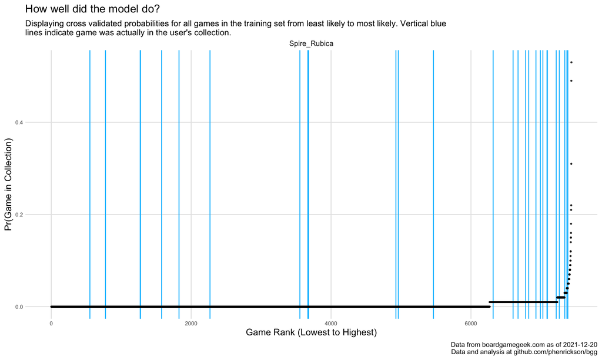

## 3.2 Top Games for **Spire_Rubica** from Training Set

We can display this information in table form, displaying the 100 games with the highest probability of ownership, adding a blue line when the user does own the game.

| username | yearpublished | game_id | name | pred_played | pred_own | actual_played | actual_own |
| --- | --- | --- | --- | --- | --- | --- | --- |
| Spire_Rubica | 2018 | 205896 | Rising Sun | 0.70 | 0.53 | 0 | 0 |
| Spire_Rubica | 2014 | 156129 | Deception: Murder in Hong Kong | 0.38 | 0.49 | 1 | 0 |
| Spire_Rubica | 2017 | 228341 | Pulsar 2849 | 0.11 | 0.31 | 0 | 0 |
| Spire_Rubica | 2005 | 15062 | Shadows over Camelot | 0.31 | 0.22 | 0 | 0 |
| Spire_Rubica | 2015 | 178900 | Codenames | 0.06 | 0.21 | 1 | 0 |
| Spire_Rubica | 2018 | 225694 | Decrypto | 0.05 | 0.18 | 0 | 0 |
| Spire_Rubica | 2012 | 119391 | Il Vecchio | 0.08 | 0.16 | 0 | 0 |
| Spire_Rubica | 2018 | 244711 | Newton | 0.63 | 0.15 | 0 | 0 |
| Spire_Rubica | 2019 | 273477 | Obscurio | 0.20 | 0.15 | 0 | 0 |
| Spire_Rubica | 2019 | 270971 | Era: Medieval Age | 0.16 | 0.14 | 0 | 0 |
| Spire_Rubica | 2016 | 198454 | When I Dream | 0.33 | 0.12 | 0 | 0 |
| Spire_Rubica | 2004 | 9220 | Saboteur | 0.24 | 0.12 | 0 | 0 |
| Spire_Rubica | 2017 | 220775 | Codenames: Disney – Family Edition | 0.10 | 0.11 | 0 | 0 |
| Spire_Rubica | 2019 | 275467 | Letter Jam | 0.06 | 0.10 | 0 | 0 |
| Spire_Rubica | 2016 | 167791 | Terraforming Mars | 0.08 | 0.10 | 1 | 0 |
| Spire_Rubica | 2019 | 283863 | The Magnificent | 0.52 | 0.09 | 0 | 0 |
| Spire_Rubica | 2018 | 231327 | The Grizzled: Armistice Edition | 0.07 | 0.09 | 0 | 0 |
| Spire_Rubica | 2019 | 265736 | Tiny Towns | 0.22 | 0.09 | 0 | 0 |
| Spire_Rubica | 2018 | 167355 | Nemesis | 0.11 | 0.09 | 0 | 0 |
| Spire_Rubica | 2013 | 52461 | Legacy: The Testament of Duke de Crecy | 0.14 | 0.08 | 0 | 0 |
| Spire_Rubica | 2019 | 266507 | Clank!: Legacy – Acquisitions Incorporated | 0.10 | 0.08 | 0 | 0 |
| Spire_Rubica | 2008 | 38159 | Ultimate Werewolf: Ultimate Edition | 0.26 | 0.08 | 0 | 0 |
| Spire_Rubica | 2018 | 245422 | Werewords Deluxe Edition | 0.13 | 0.08 | 0 | 0 |
| Spire_Rubica | 2015 | 171668 | The Grizzled | 0.09 | 0.08 | 0 | 0 |
| Spire_Rubica | 2017 | 217861 | Paper Tales | 0.17 | 0.08 | 1 | 0 |
| Spire_Rubica | 2014 | 161970 | Alchemists | 0.12 | 0.07 | 0 | 0 |
| Spire_Rubica | 2014 | 164265 | Witness | 0.09 | 0.07 | 0 | 0 |
| Spire_Rubica | 2010 | 62219 | Dominant Species | 0.20 | 0.07 | 0 | 0 |
| Spire_Rubica | 2016 | 205716 | New Angeles | 0.23 | 0.07 | 0 | 0 |
| Spire_Rubica | 2017 | 233078 | Twilight Imperium: Fourth Edition | 0.14 | 0.07 | 0 | 0 |

[output cut: 70 more lines]

We can also more formally assess how well the model did in resampling by looking at the area under the receiver operating characteristic. A perfect model would receive a score of 1, while a model that cannot predict the outcome will default to a score of 0.5. The extent to which something is a *good* score depends on the setting, but generally anything in the .8 to .9 range is very good while the .7 to .8 range is perfectly acceptable.

| username | outcome_type | .metric | .estimator | .estimate |
| --- | --- | --- | --- | --- |
| Spire_Rubica | own | roc_auc | binary | 0.814 |
| Spire_Rubica | played | roc_auc | binary | 0.837 |

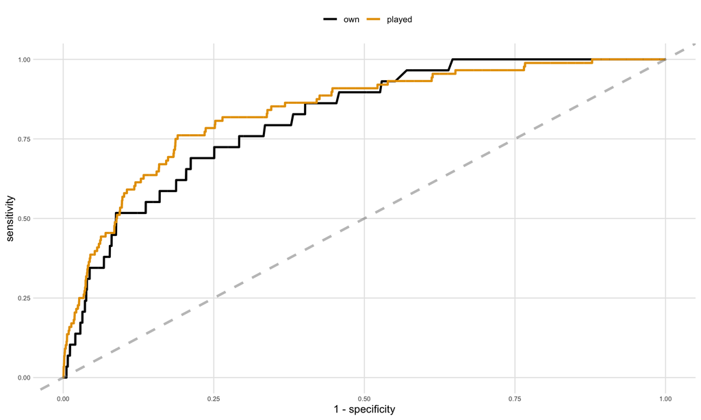

Another way to think about the model performance is to view its lift, or its ability to detect the positive outcomes over that of a null model. High lift indicates the model can much more quickly find all of the positive outcomes (in this case, games owned or played by the user), while a model with no lift is no better than random guessing.

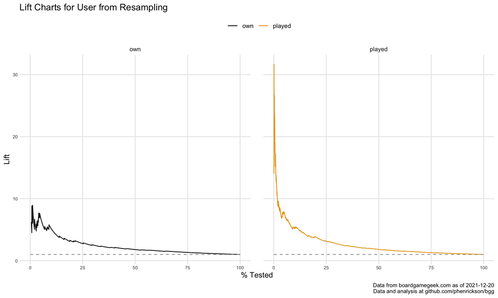

## 3.3 Most and Least Likely Games

What games does the model think Spire_Rubica is **most likely to own** that are **not** in their collection?

| username | yearpublished | game_id | name | pred_own | actual_own |
| --- | --- | --- | --- | --- | --- |
| Spire_Rubica | 2018 | 205896 | Rising Sun | 0.53 | 0 |
| Spire_Rubica | 2014 | 156129 | Deception: Murder in Hong Kong | 0.49 | 0 |
| Spire_Rubica | 2017 | 228341 | Pulsar 2849 | 0.31 | 0 |
| Spire_Rubica | 2005 | 15062 | Shadows over Camelot | 0.22 | 0 |
| Spire_Rubica | 2015 | 178900 | Codenames | 0.21 | 0 |

What games does the model think Spire_Rubica is **least likely to own** that **are** in their collection?

| username | yearpublished | game_id | name | pred_own | actual_own |
| --- | --- | --- | --- | --- | --- |
| Spire_Rubica | 2015 | 173346 | 7 Wonders Duel | 0 | 1 |
| Spire_Rubica | 2014 | 160477 | Onitama | 0 | 1 |
| Spire_Rubica | 2018 | 231733 | Obsession | 0 | 1 |
| Spire_Rubica | 2018 | 237182 | Root | 0 | 1 |
| Spire_Rubica | 2007 | 28143 | Race for the Galaxy | 0 | 1 |

## 3.4 Top Games by Year

Top 25 games most likely to be owned by the user in each year, highlighting in blue the games that the user has owned/played.

| rank | 2011 | 2012 | 2013 | 2014 | 2015 | 2016 | 2017 | 2018 | 2019 |
| --- | --- | --- | --- | --- | --- | --- | --- | --- | --- |
| 1 | Discworld: Ankh-Morpork | Il Vecchio | Legacy: The Testament of Duke de Crecy | Deception: Murder in Hong Kong | Codenames | When I Dream | Pulsar 2849 | Rising Sun | Obscurio |
| 2 | Mage Knight Board Game | Targi | Room 25 | Alchemists | The Grizzled | Terraforming Mars | Codenames: Disney – Family Edition | Decrypto | Era: Medieval Age |
| 3 | Dark Moon | The Resistance: Avalon | Concept | Witness | Tiny Epic Galaxies | New Angeles | Paper Tales | Newton | Letter Jam |
| 4 | Eclipse | Smash Up | Metallum | Ultimate Werewolf | Blood Rage | Codenames: Pictures | Twilight Imperium: Fourth Edition | The Grizzled: Armistice Edition | The Magnificent |
| 5 | Panic Station | Archipelago | Titanium Wars | Spyfall | Salem 1692 | Inis | The Godfather: Corleone's Empire | Nemesis | Tiny Towns |
| 6 | Ascension: Return of the Fallen | Kairo | Eight-Minute Empire: Legends | Legendary Encounters: An Alien Deck Building Game | Through the Ages: A New Story of Civilization | Clank!: A Deck-Building Adventure | Gaia Project | Werewords Deluxe Edition | Clank!: Legacy – Acquisitions Incorporated |
| 7 | Space Empires: 4X | One Night Werewolf | Steam Park | Dead of Winter: A Crossroads Game | One Night Revolution | Bloodborne: The Card Game | Codenames: Duet | Who Goes There? | Amul |
| 8 | Takenoko | Suburbia | Patchistory | Sheriff of Nottingham | One Night Ultimate Vampire | Captain Sonar | Bunny Kingdom | Codenames: Harry Potter | The Isle of Cats |
| 9 | Tragedy Looper | Tzolk'in: The Mayan Calendar | Mascarade | Imperial Settlers | The Pursuit of Happiness | Timebomb | Smash Up: What Were We Thinking? | Hail Hydra | Medium |
| 10 | Mundus Novus | Among the Stars | Ultimate Werewolf: Inquisition | Castles of Mad King Ludwig | Smash Up: Munchkin | Codenames: Deep Undercover | Fog of Love | First Contact | One Key |
| 11 | Star Trek Deck Building Game: The Next Generation | Zombicide | World of Tanks: Rush | Artifacts, Inc. | The Builders: Antiquity | The Oregon Trail Card Game | Photosynthesis | Architects of the West Kingdom | Wingspan |
| 12 | Nightfall | Uchronia | Lewis & Clark: The Expedition | Splendor | 504 | Secret Hitler | Dragon Castle | New Frontiers | Tapestry |
| 13 | Nightfall: Martial Law | Kemet | Crusade and Revolution: The Spanish Civil War, 1936-1939 | Sheep & Thief | Steampunk Rally | Kanagawa | Battlestations: Second Edition | Duelosaur Island | Hadara |
| 14 | Core Worlds | Eight-Minute Empire | Smash Up: Awesome Level 9000 | Stay Away! | Mysterium | Behind the Throne | Tortuga 1667 | Everdell | Harry Potter: Hogwarts Battle – Defence Against the Dark Arts |
| 15 | A Few Acres of Snow | For the Crown (Second Edition) | Smash Up: The Obligatory Cthulhu Set | King of New York | One Night Ultimate Werewolf: Daybreak | Dream Home | A Column of Fire | Gizmos | Aquatica |
| 16 | Omen: A Reign of War | Morels | The Ravens of Thri Sahashri | One Night Ultimate Werewolf | ...and then, we held hands. | Islebound | Dice Forge | Azul: Stained Glass of Sintra | Last Bastion |
| 17 | 1911 Amundsen vs Scott | Pixel Tactics | Ascension: Apprentice Edition | Smash Up: Science Fiction Double Feature | Smash Up: Pretty Pretty Smash Up | Kreus | Azul | The World of SMOG: Rise of Moloch | Azul: Summer Pavilion |
| 18 | Ventura | Equinox | Field of Glory: The Card Game | Akrotiri | Sylvion | Time Bomb Evolution | Majesty: For the Realm | A Song of Ice & Fire: Tabletop Miniatures Game – Stark vs Lannister Starter Set | Sherlock: Don's Legacy |
| 19 | Drum Roll | Star Trek Deck Building Game: The Next Generation – Next Phase | Hanamikoji | Smash Up: Monster Smash | KUNE v LAKIA: A Chronicle Of A Royal Lapine Divorce Foretold | The Networks | A Handful of Stars | Smash Up: That '70s Expansion | Zombicide: Invader |
| 20 | Principato | Starship Merchants | Pizza Party | Draco Magi | Holmes: Sherlock & Mycroft | Habitats | Seeders from Sereis: Exodus | Lords of Hellas | GROWL |
| 21 | Pantheon | Star Trek Deck Building Game: The Original Series | City of Remnants | Patchwork | Star Realms: Colony Wars | Oceanos | Codenames: Marvel | Underwater Cities | Crusader Kings |
| 22 | The Gnomes of Zavandor | Mice and Mystics | The Witches: A Discworld Game | Star Realms | Tiger Leader | Tales & Games: The Pied Piper | Muse | Cahoots | Villagers |
| 23 | Singapore | Sunrise City | Theseus: The Dark Orbit | Sellswords | Hostage Negotiator | Smash Up: It's Your Fault! | Ethnos | Sprawlopolis | It's a Wonderful World |
| 24 | Feudalia | Seasons | The Quiet Year | The Ancient World | Chaosmos | 13 Days: The Cuban Missile Crisis | Custom Heroes | Trapwords | Monster Baby Rescue! |
| 25 | Urban Sprawl | Africana | Glass Road | Imperialism: Road to Domination | T.I.M.E Stories | Agility | One Night Ultimate Alien | Pax Emancipation | Pictures |

## 3.5 Interactive Predictions from Resampling

Interactive table for predictions from resampling.

|  | username | yearpublished | rank | game_id | name | pred_played | pred_own | actual_played | actual_own |
| --- | --- | --- | --- | --- | --- | --- | --- | --- | --- |
| 1 | Spire_Rubica | 1900 | 856 | 5432 | Chutes and Ladders | 0.01 | 0.01 | 0 | 0 |
| 2 | Spire_Rubica | 1900 | 1183 | 5546 | Marbles | 0 | 0 | 0 | 0 |
| 3 | Spire_Rubica | 1900 | 1186 | 11901 | Tic-Tac-Toe | 0.01 | 0 | 0 | 0 |
| 4 | Spire_Rubica | 1900 | 1235 | 188 | Go | 0 | 0 | 0 | 0 |
| 5 | Spire_Rubica | 1900 | 1346 | 171 | Chess | 0 | 0 | 0 | 0 |
| 6 | Spire_Rubica | 1900 | 1356 | 2065 | Shogi | 0 | 0 | 0 | 0 |
| 7 | Spire_Rubica | 1900 | 1357 | 2393 | Xiangqi | 0 | 0 | 0 | 0 |
| 8 | Spire_Rubica | 1900 | 1566 | 26952 | International Checkers | 0.01 | 0 | 0 | 0 |
| 9 | Spire_Rubica | 1900 | 1603 | 1602 | The Royal Game of Ur | 0.02 | 0 | 0 | 0 |
| 10 | Spire_Rubica | 1900 | 1604 | 2083 | Checkers | 0.01 | 0 | 0 | 0 |

[output cut: 7426 more lines]

# 4 Validating the Model on 2020

How well did a model trained on a user’s collection through 2019 perform in predicting games for the user from 2020?

| username | outcome_type | yearpublished | .metric | .estimator | .estimate |
| --- | --- | --- | --- | --- | --- |
| Spire_Rubica | own | 2020 | roc_auc | binary | 0.833 |
| Spire_Rubica | played | 2020 | roc_auc | binary | 0.862 |

Table of top 25 games from 2020, highlighting games that the user owns.

| username | yearpublished | game_id | name | pred_own | pred_played | actual_own | actual_played |
| --- | --- | --- | --- | --- | --- | --- | --- |
| Spire_Rubica | 2020 | 184267 | On Mars | 0.08 | 0.26 | 0 | 0 |
| Spire_Rubica | 2020 | 291457 | Gloomhaven: Jaws of the Lion | 0.07 | 0.22 | 1 | 1 |
| Spire_Rubica | 2020 | 292333 | Cowboys II: Cowboys & Indians Edition | 0.07 | 0.19 | 0 | 0 |
| Spire_Rubica | 2020 | 306481 | Tawantinsuyu: The Inca Empire | 0.04 | 0.07 | 0 | 0 |
| Spire_Rubica | 2020 | 323784 | Ghost Letters | 0.04 | 0.21 | 0 | 0 |
| Spire_Rubica | 2020 | 262939 | Far Away | 0.03 | 0.03 | 0 | 0 |
| Spire_Rubica | 2020 | 296517 | Contact: Signals from Outer Space | 0.03 | 0.03 | 0 | 0 |
| Spire_Rubica | 2020 | 301767 | Mysterium Park | 0.03 | 0.11 | 1 | 1 |
| Spire_Rubica | 2020 | 307844 | Atheneum: Mystic Library | 0.03 | 0.12 | 0 | 0 |
| Spire_Rubica | 2020 | 307997 | Insider Black | 0.03 | 0.17 | 0 | 0 |
| Spire_Rubica | 2020 | 313008 | Apollo: A Game Inspired by NASA Moon Missions | 0.03 | 0.03 | 0 | 0 |
| Spire_Rubica | 2020 | 313817 | Hello Neighbor: The Secret Neighbor Party Game | 0.03 | 0.18 | 0 | 0 |
| Spire_Rubica | 2020 | 316377 | 7 Wonders (Second Edition) | 0.03 | 0.14 | 0 | 0 |
| Spire_Rubica | 2020 | 246900 | Eclipse: Second Dawn for the Galaxy | 0.02 | 0.04 | 0 | 0 |
| Spire_Rubica | 2020 | 252153 | Tang Garden | 0.02 | 0.04 | 0 | 0 |
| Spire_Rubica | 2020 | 256317 | Guild Master | 0.02 | 0.12 | 0 | 0 |
| Spire_Rubica | 2020 | 257193 | Starcadia Quest | 0.02 | 0.03 | 0 | 0 |
| Spire_Rubica | 2020 | 296483 | The Great Race | 0.02 | 0.05 | 0 | 0 |
| Spire_Rubica | 2020 | 296498 | 10 Dice | 0.02 | 0.03 | 0 | 0 |
| Spire_Rubica | 2020 | 297030 | Tekhenu: Obelisk of the Sun | 0.02 | 0.10 | 0 | 0 |
| Spire_Rubica | 2020 | 298352 | The Shining | 0.02 | 0.04 | 0 | 0 |
| Spire_Rubica | 2020 | 298371 | Wild Space | 0.02 | 0.03 | 0 | 0 |
| Spire_Rubica | 2020 | 298638 | Sheriff of Nottingham (2nd Edition) | 0.02 | 0.05 | 0 | 0 |
| Spire_Rubica | 2020 | 302734 | Master Word | 0.02 | 0.04 | 0 | 0 |
| Spire_Rubica | 2020 | 310885 | Belaad: The Land of Swords and Quills | 0.02 | 0.04 | 0 | 0 |

# 5 Predicting Upcoming Games (2020 and On) for **Spire_Rubica**

Examine the top games for the test set.

| username | yearpublished | game_id | name | rank | own | played |
| --- | --- | --- | --- | --- | --- | --- |
| Spire_Rubica | 2020 | 184267 | On Mars | 1 | 0.08 | 0.26 |
| Spire_Rubica | 2020 | 292333 | Cowboys II: Cowboys & Indians Edition | 2 | 0.07 | 0.19 |
| Spire_Rubica | 2020 | 291457 | Gloomhaven: Jaws of the Lion | 3 | 0.07 | 0.22 |
| Spire_Rubica | 2020 | 306481 | Tawantinsuyu: The Inca Empire | 4 | 0.04 | 0.07 |
| Spire_Rubica | 2020 | 323784 | Ghost Letters | 5 | 0.04 | 0.21 |
| Spire_Rubica | 2020 | 296517 | Contact: Signals from Outer Space | 6 | 0.03 | 0.03 |
| Spire_Rubica | 2020 | 316377 | 7 Wonders (Second Edition) | 7 | 0.03 | 0.14 |
| Spire_Rubica | 2020 | 307997 | Insider Black | 8 | 0.03 | 0.17 |
| Spire_Rubica | 2020 | 307844 | Atheneum: Mystic Library | 9 | 0.03 | 0.12 |
| Spire_Rubica | 2020 | 313008 | Apollo: A Game Inspired by NASA Moon Missions | 10 | 0.03 | 0.03 |
| Spire_Rubica | 2020 | 301767 | Mysterium Park | 11 | 0.03 | 0.11 |
| Spire_Rubica | 2020 | 313817 | Hello Neighbor: The Secret Neighbor Party Game | 12 | 0.03 | 0.18 |
| Spire_Rubica | 2020 | 262939 | Far Away | 13 | 0.03 | 0.03 |
| Spire_Rubica | 2020 | 298371 | Wild Space | 14 | 0.02 | 0.03 |
| Spire_Rubica | 2020 | 312484 | Lost Ruins of Arnak | 15 | 0.02 | 0.03 |
| Spire_Rubica | 2020 | 298352 | The Shining | 16 | 0.02 | 0.04 |
| Spire_Rubica | 2020 | 312346 | Munchkin Disney | 17 | 0.02 | 0.02 |
| Spire_Rubica | 2020 | 319966 | The King Is Dead: Second Edition | 18 | 0.02 | 0.05 |
| Spire_Rubica | 2020 | 310885 | Belaad: The Land of Swords and Quills | 19 | 0.02 | 0.04 |
| Spire_Rubica | 2020 | 296483 | The Great Race | 20 | 0.02 | 0.05 |
| Spire_Rubica | 2020 | 316554 | Dune: Imperium | 21 | 0.02 | 0.06 |
| Spire_Rubica | 2020 | 256317 | Guild Master | 22 | 0.02 | 0.12 |
| Spire_Rubica | 2020 | 313698 | Monster Expedition | 23 | 0.02 | 0.06 |
| Spire_Rubica | 2020 | 297030 | Tekhenu: Obelisk of the Sun | 24 | 0.02 | 0.10 |
| Spire_Rubica | 2020 | 246900 | Eclipse: Second Dawn for the Galaxy | 25 | 0.02 | 0.04 |
| Spire_Rubica | 2021 | 298102 | Roll Camera!: The Filmmaking Board Game | 1 | 0.22 | 0.33 |
| Spire_Rubica | 2021 | 291847 | Mantis Falls | 2 | 0.08 | 0.30 |
| Spire_Rubica | 2021 | 340466 | Unfathomable | 3 | 0.07 | 0.17 |
| Spire_Rubica | 2021 | 283387 | Rocketmen | 4 | 0.06 | 0.11 |
| Spire_Rubica | 2021 | 335541 | We Care: a Grizzled Game | 5 | 0.06 | 0.09 |
| Spire_Rubica | 2021 | 249277 | Brazil: Imperial | 6 | 0.05 | 0.09 |
| Spire_Rubica | 2021 | 326804 | Rorschach | 7 | 0.04 | 0.04 |
| Spire_Rubica | 2021 | 316287 | Quest | 8 | 0.04 | 0.24 |
| Spire_Rubica | 2021 | 285967 | Ankh: Gods of Egypt | 9 | 0.04 | 0.17 |
| Spire_Rubica | 2021 | 310100 | Nemesis: Lockdown | 10 | 0.04 | 0.08 |
| Spire_Rubica | 2021 | 273330 | Bloodborne: The Board Game | 11 | 0.03 | 0.06 |
| Spire_Rubica | 2021 | 309408 | Arcana Rising | 12 | 0.03 | 0.10 |
| Spire_Rubica | 2021 | 324856 | The Crew: Mission Deep Sea | 13 | 0.03 | 0.04 |
| Spire_Rubica | 2021 | 331635 | Kameloot | 14 | 0.03 | 0.06 |
| Spire_Rubica | 2021 | 309319 | Apogee | 15 | 0.03 | 0.04 |
| Spire_Rubica | 2021 | 333553 | For the King (and Me) | 16 | 0.03 | 0.09 |
| Spire_Rubica | 2021 | 336552 | Mystic Paths | 17 | 0.03 | 0.04 |
| Spire_Rubica | 2021 | 318084 | Furnace | 18 | 0.03 | 0.06 |
| Spire_Rubica | 2021 | 291859 | Riftforce | 19 | 0.03 | 0.27 |
| Spire_Rubica | 2021 | 342942 | Ark Nova | 20 | 0.03 | 0.11 |
| Spire_Rubica | 2021 | 310873 | Carnegie | 21 | 0.03 | 0.10 |
| Spire_Rubica | 2021 | 343905 | Boonlake | 22 | 0.02 | 0.07 |
| Spire_Rubica | 2021 | 295147 | Good Puppers | 23 | 0.02 | 0.04 |
| Spire_Rubica | 2021 | 306182 | Bandada | 24 | 0.02 | 0.04 |
| Spire_Rubica | 2021 | 265635 | Space Race | 25 | 0.02 | 0.02 |
| Spire_Rubica | 2022 | 317511 | Tindaya | 1 | 0.06 | 0.17 |
| Spire_Rubica | 2022 | 283137 | Human Punishment: The Beginning | 2 | 0.05 | 0.22 |
| Spire_Rubica | 2022 | 331106 | The Witcher: Old World | 3 | 0.03 | 0.20 |
| Spire_Rubica | 2022 | 295770 | Frosthaven | 4 | 0.03 | 0.09 |
| Spire_Rubica | 2022 | 325494 | ISS Vanguard | 5 | 0.02 | 0.02 |
| Spire_Rubica | 2022 | 258779 | Planet Unknown | 6 | 0.02 | 0.02 |
| Spire_Rubica | 2022 | 324090 | Scarface 1920 | 7 | 0.02 | 0.05 |
| Spire_Rubica | 2022 | 326945 | Castles of Mad King Ludwig: Collector's Edition | 8 | 0.02 | 0.05 |
| Spire_Rubica | 2022 | 335427 | Wild: Serengeti | 9 | 0.02 | 0.05 |
| Spire_Rubica | 2022 | 330950 | Age of Galaxy | 10 | 0.02 | 0.04 |
| Spire_Rubica | 2022 | 304051 | Creature Comforts | 11 | 0.02 | 0.07 |
| Spire_Rubica | 2022 | 318450 | Bios: Mesofauna | 12 | 0.01 | 0.01 |
| Spire_Rubica | 2022 | 327711 | It's a Wonderful Kingdom | 13 | 0.01 | 0.01 |
| Spire_Rubica | 2022 | 254632 | Hyperspace | 14 | 0.01 | 0.01 |
| Spire_Rubica | 2022 | 322524 | Bardsung | 15 | 0.01 | 0.03 |
| Spire_Rubica | 2022 | 227935 | Wonderland's War | 16 | 0.01 | 0.01 |
| Spire_Rubica | 2022 | 329551 | Mosaic: A Story of Civilization | 17 | 0.01 | 0.01 |
| Spire_Rubica | 2022 | 306311 | Eternal Palace | 18 | 0.01 | 0.02 |
| Spire_Rubica | 2022 | 336986 | Flamecraft | 19 | 0.01 | 0.02 |
| Spire_Rubica | 2022 | 345868 | Federation | 20 | 0.01 | 0.02 |
| Spire_Rubica | 2022 | 287871 | Hybris: Disordered Cosmos | 21 | 0.01 | 0.02 |
| Spire_Rubica | 2022 | 322589 | Zapotec | 22 | 0.01 | 0.02 |
| Spire_Rubica | 2022 | 281647 | Stellaris: Infinite Legacy | 23 | 0.01 | 0.01 |
| Spire_Rubica | 2022 | 266064 | Trudvang Legends | 24 | 0.01 | 0.01 |
| Spire_Rubica | 2022 | 295374 | Long Shot: The Dice Game | 25 | 0.01 | 0.04 |

## 5.1 Interactive Table for Upcoming Games 2020 and On

|  | username | yearpublished | game_id | name | rank | own | played |
| --- | --- | --- | --- | --- | --- | --- | --- |
| 1 | Spire_Rubica | 2021 | 298102 | Roll Camera!: The Filmmaking Board Game | 1 | 0.22 | 0.33 |
| 2 | Spire_Rubica | 2021 | 291847 | Mantis Falls | 2 | 0.08 | 0.3 |
| 3 | Spire_Rubica | 2020 | 184267 | On Mars | 3 | 0.08 | 0.26 |
| 4 | Spire_Rubica | 2020 | 292333 | Cowboys II: Cowboys &amp; Indians Edition | 4 | 0.07 | 0.19 |
| 5 | Spire_Rubica | 2021 | 340466 | Unfathomable | 5 | 0.07 | 0.17 |
| 6 | Spire_Rubica | 2020 | 291457 | Gloomhaven: Jaws of the Lion | 6 | 0.07 | 0.22 |
| 7 | Spire_Rubica | 2021 | 283387 | Rocketmen | 7 | 0.06 | 0.11 |
| 8 | Spire_Rubica | 2021 | 335541 | We Care: a Grizzled Game | 8 | 0.06 | 0.09 |
| 9 | Spire_Rubica | 2022 | 317511 | Tindaya | 9 | 0.06 | 0.17 |
| 10 | Spire_Rubica | 2021 | 249277 | Brazil: Imperial | 10 | 0.05 | 0.09 |

[output cut: 1627 more lines]